# Cluster

Maksym Rud’

22 11 2020

## R Markdown

As we don’t want the clustering algorithm to depend to an arbitrary variable unit, we start by scaling/standardizing the data.

```r
df <- scale(df)
head(df, n = 3)
```

```
##             Murder   Assault   UrbanPop         Rape
## Alabama 1.24256408 0.7828393 -0.5209066 -0.003416473
## Alaska  0.50786248 1.1068225 -1.2117642  2.484202941
## Arizona 0.07163341 1.4788032  0.9989801  1.042878388
```

## Finding optimal number of clusters

Here, we provide a simple solution. The idea is to compute k-means clustering using di erent values of clusters k. Next, the wss (within sum of square) is drawn according to the number of clusters. The location of a bend (knee) in the plot is generally considered as an indicator of the appropriate number of clusters.

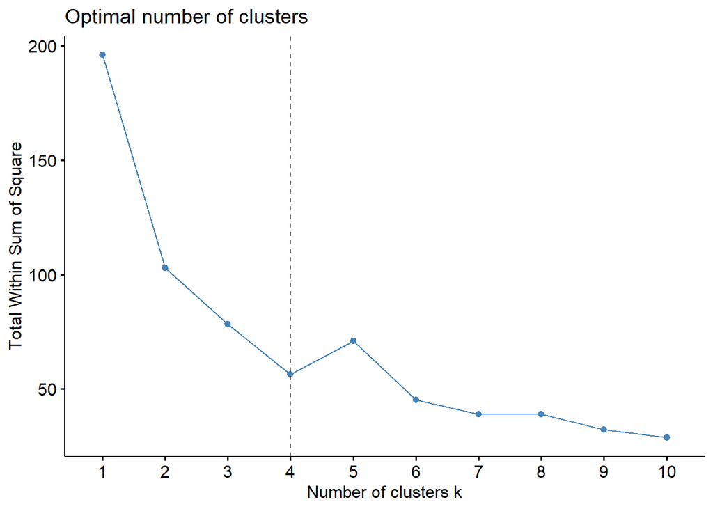

```r
fviz_nbclust(df, kmeans, method = "wss") +
geom_vline(xintercept = 4, linetype = 2)
```

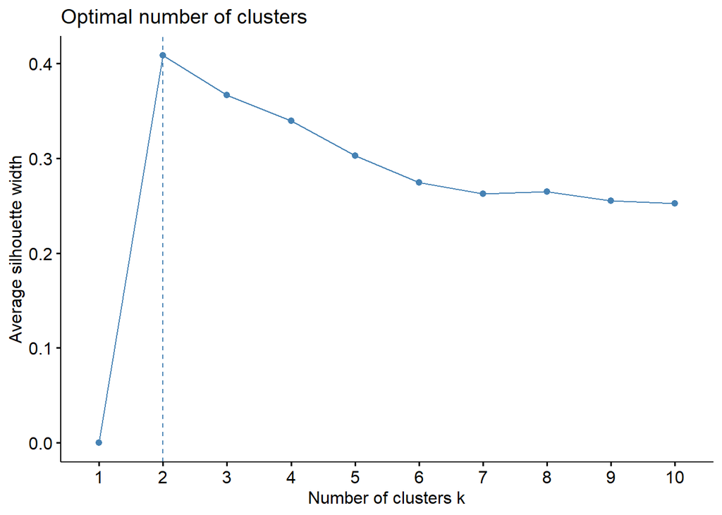

```r
fviz_nbclust(df, kmeans, method = "silhouette")
```

## Compute k-mean clustering

As k-means clustering algorithm starts with k randomly selected centroids, it’s always recommended to use the set.seed() function in order to set a seed for R’s random number generator. The aim is to make reproducible the results, so that the reader of this article will obtain exactly the same results as those shown below.

```r
set.seed(123)
km.res <- kmeans(df, 4, nstart = 25)
```

### Result

```r
print(km.res)
```

```
## K-means clustering with 4 clusters of sizes 8, 13, 16, 13
##
## Cluster means:
##       Murder    Assault   UrbanPop        Rape
## 1  1.4118898  0.8743346 -0.8145211  0.01927104
## 2 -0.9615407 -1.1066010 -0.9301069 -0.96676331
## 3 -0.4894375 -0.3826001  0.5758298 -0.26165379
## 4  0.6950701  1.0394414  0.7226370  1.27693964
##
## Clustering vector:
##        Alabama         Alaska        Arizona       Arkansas     California
##              1              4              4              1              4
##       Colorado    Connecticut       Delaware        Florida        Georgia
##              4              3              3              4              1
##         Hawaii          Idaho       Illinois        Indiana           Iowa
##              3              2              4              3              2
##         Kansas       Kentucky      Louisiana          Maine       Maryland
##              3              2              1              2              4
##  Massachusetts       Michigan      Minnesota    Mississippi       Missouri
##              3              4              2              1              4
##        Montana       Nebraska         Nevada  New Hampshire     New Jersey
##              2              2              4              2              3
##     New Mexico       New York North Carolina   North Dakota           Ohio
##              4              4              1              2              3
##       Oklahoma         Oregon   Pennsylvania   Rhode Island South Carolina
##              3              3              3              3              1
##   South Dakota      Tennessee          Texas           Utah        Vermont
##              2              1              4              3              2
##       Virginia     Washington  West Virginia      Wisconsin        Wyoming
##              3              3              2              2              3
##
## Within cluster sum of squares by cluster:
## [1]  8.316061 11.952463 16.212213 19.922437
##  (between_SS / total_SS =  71.2 %)
##
## Available components:
##
## [1] "cluster"      "centers"      "totss"        "withinss"     "tot.withinss"
## [6] "betweenss"    "size"         "iter"         "ifault"
```

```r
aggregate(USArrests, by = list(cluster=km.res$cluster), mean)
```

```
##   cluster   Murder   Assault UrbanPop     Rape
## 1       1 13.93750 243.62500 53.75000 21.41250
## 2       2  3.60000  78.53846 52.07692 12.17692
## 3       3  5.65625 138.87500 73.87500 18.78125
## 4       4 10.81538 257.38462 76.00000 33.19231
```

```r
dd <- cbind(USArrests, cluster = km.res$cluster)
head(dd)
```

```
##            Murder Assault UrbanPop Rape cluster
## Alabama      13.2     236       58 21.2       1
## Alaska       10.0     263       48 44.5       4
## Arizona       8.1     294       80 31.0       4
## Arkansas      8.8     190       50 19.5       1
## California    9.0     276       91 40.6       4
## Colorado      7.9     204       78 38.7       4
```

```r
km.res$size
```

```
## [1]  8 13 16 13
```

## Visualizing

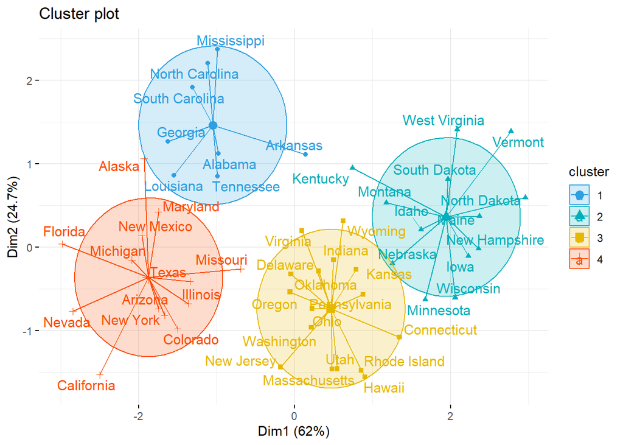

```r
fviz_cluster(km.res, data = df, palette = c("#2E9FDF", "#00AFBB", "#E7B800", "#FC4E07"),
  ellipse.type = "euclid", # Concentration ellipse
  star.plot = TRUE, # Add segments from centroids to items
  repel = TRUE, # Avoid label overplotting (slow)
  ggtheme = theme_minimal()
  )
```

## Using hierarchical K-Means Clustering

The algorithm is summarized as follow: 1. Compute hierarchical clustering and cut the tree into k-clusters 2. Compute the center (i.e the mean) of each cluster 3. Compute k-means by using the set of cluster centers (defined in step 2) as the initial cluster centers

```r
res.hk <- hkmeans(df, 4)
```

## Visualize the tree

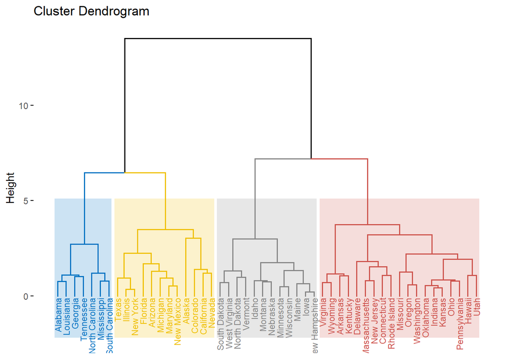

```r
fviz_dend(res.hk, cex = 0.6, palette = "jco",
          rect = TRUE, rect_border = "jco", rect_fill = TRUE)
```

## Visualize the hkmeans final clusters

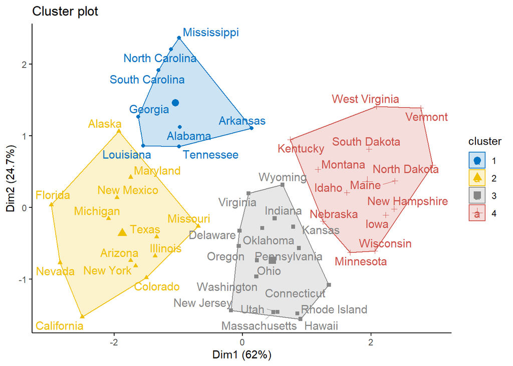

```r
fviz_cluster(res.hk, palette = "jco", repel = TRUE,
             ggtheme = theme_classic())
```

## Compare Results

```r
rand.index(res.hk$cluster, km.res$cluster)
```

```
## [1] 1
```

## Fuzzy clustering

```r
cm <- cmeans(df, 4)
cm
```

```
## Fuzzy c-means clustering with 4 clusters
##
## Cluster centers:
##       Murder    Assault   UrbanPop       Rape
## 1 -1.0617737 -1.0915457 -0.9388321 -1.0274248
## 2 -0.4301420 -0.4532686  0.4309782 -0.2133483
## 3  1.3468197  0.8712430 -0.6189499  0.1553107
## 4  0.6661515  1.0463022  0.8007386  1.1964155
##
## Memberships:
##                          1           2          3          4
## Alabama        0.005167403 0.009839637 0.97052405 0.01446891
## Alaska         0.111958190 0.165990475 0.33757177 0.38447957
## Arizona        0.030245590 0.081878753 0.08922730 0.79864835
## Arkansas       0.197115692 0.258027328 0.41443181 0.13042517
## California     0.054021033 0.125519567 0.12323392 0.69722548
## Colorado       0.056799789 0.156762031 0.12038905 0.66604913
## Connecticut    0.255368680 0.605262066 0.06812966 0.07123959
## Delaware       0.139698638 0.496135121 0.17624406 0.18792218
## Florida        0.048431491 0.097540582 0.25138938 0.60263855
## Georgia        0.047376780 0.083152315 0.70686902 0.16260189
## Hawaii         0.183452308 0.623331066 0.08454065 0.10867597
## Idaho          0.827642405 0.119309473 0.03019734 0.02285078
## Illinois       0.047275321 0.162151962 0.15986375 0.63070896
## Indiana        0.109311336 0.775972520 0.06182701 0.05288913
## Iowa           0.901069868 0.068301927 0.01696477 0.01366343
## Kansas         0.094340449 0.847916251 0.03091517 0.02682813
## Kentucky       0.347273593 0.325298382 0.22861929 0.09880874
## Louisiana      0.031327542 0.064258404 0.75411612 0.15029793
## Maine          0.926760696 0.045721182 0.01594223 0.01157589
## Maryland       0.037160722 0.083252092 0.34415721 0.53542997
## Massachusetts  0.121692507 0.695833665 0.07499488 0.10747895
## Michigan       0.012141110 0.029675951 0.06245644 0.89572650
## Minnesota      0.518905520 0.387534087 0.04827995 0.04528044
## Mississippi    0.074875642 0.091828269 0.72180747 0.11148862
## Missouri       0.074557551 0.340440556 0.19820944 0.38679245
## Montana        0.605970588 0.265475442 0.07955347 0.04900050
## Nebraska       0.435298091 0.476116191 0.04823460 0.04035112
## Nevada         0.057887274 0.118945282 0.16477653 0.65839091
## New Hampshire  0.907715916 0.061828557 0.01704935 0.01340618
```

[output cut: 32 more lines]

```
##              2              4              1              3              4
##        Montana       Nebraska         Nevada  New Hampshire     New Jersey
##              1              2              4              1              2
##     New Mexico       New York North Carolina   North Dakota           Ohio
##              4              4              3              1              2
##       Oklahoma         Oregon   Pennsylvania   Rhode Island South Carolina
##              2              2              2              2              3
##   South Dakota      Tennessee          Texas           Utah        Vermont
##              1              3              4              2              1
##       Virginia     Washington  West Virginia      Wisconsin        Wyoming
##              2              2              1              1              2
##
## Available components:
## [1] "centers"     "size"        "cluster"     "membership"  "iter"
## [6] "withinerror" "call"
```

## Plotting clusters

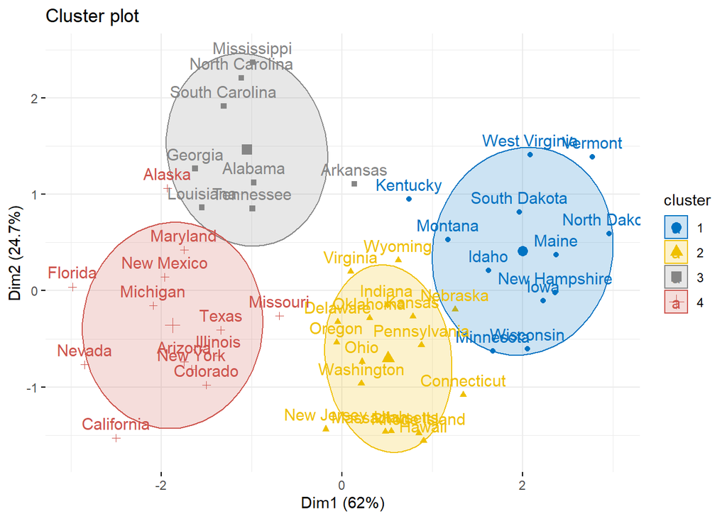

```r
fviz_cluster(list(data = df, cluster=cm$cluster),
             ellipse.type = "norm",
             ellipse.level = 0.68,
             palette = "jco",
             ggtheme = theme_minimal())
```

```r
rand.index(cm$cluster, km.res$cluster)
```

```
## [1] 0.9771429
```